# 10ma Semana 18/08/2021- Algebra, 2IEV y IEFI.

Fecha de entrega: 23/08/21

Consignas: La segunda instancia evaluativa será un trabajo individual donde deberán responder las preguntas indicadas.

El tema es algebra matricial, vinculado al entrenamiento de una red neuronal, para afianzar conceptos de uso y operaciones matriciales.

ANR significa artificial neural network

https://www.datasource.ai/es/data-science-articles/una-guia-para-principiantes-sobre-la-regresion-lineal-en-python-con-scikit-learn

https://www.iartificial.net/regresion-lineal-con-ejemplos-en-python/

## Redes Neuronales – Teoría

La programación clásica y las redes neuronales son aproximaciones distintas para resolver problemas.

En la programación clásica, escribimos código fuente indicando al ordenador qué decisiones han de tomarse de forma absolutamente determinista para resolver un problema, una descripción detallada de todo lo que hay que hacer, similar a una receta. Por ejemplo, si lo que queremos es sumar dos números, tiene sentido programar en nuestro lenguaje favorito el algoritmo de la suma.

Sin embargo, supongamos que nuestro problema es distinguir si una fotografía es un coche o no. En principio, no parece complicado cómo estructurar un algoritmo, un coche siempre tiene cuatro ruedas, ventanas, parabrisas, faros.

## Comparación de neurona humana y neurona artificial

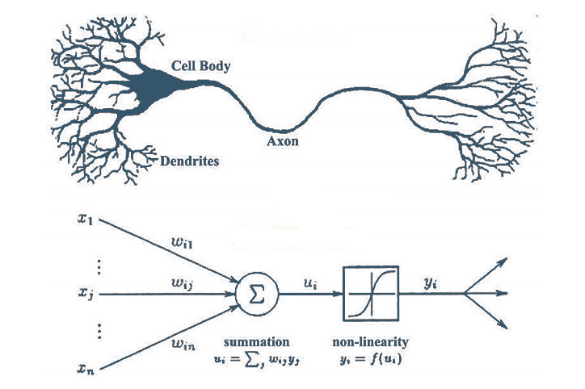

## ¿Que es una red neuronal?

Las redes neuronales artificiales (también conocidas como sistemas conexionistas) son un modelo matemático-computacional el que fue evolucionando a partir de diversas aportaciones científicas que están registradas en la historia.

Consiste en un conjunto de unidades, llamadas neuronas artificiales, conectadas entre sí para transmitirse señales. La información de entrada atraviesa la red neuronal (donde se somete a diversas operaciones) produciendo unos valores de salida.

**Cada neurona está conectada con otras a través de unos enlaces. En estos enlaces el valor de salida de la neurona anterior es multiplicado por un valor de peso.**

Estos pesos en los enlaces pueden incrementar o inhibir el estado de activación de las neuronas adyacentes. Del mismo modo, a la salida de la neurona, puede existir una función limitadora o umbral, que modifica el valor resultado o impone un límite que no se debe sobrepasar antes de propagarse a otra neurona.

**Esta función se conoce como función de activación.**

Estos sistemas aprenden y se forman a sí mismos, en lugar de ser programados de forma explícita, y sobresalen en áreas donde la detección de soluciones o características es difícil de expresar con la programación convencional.

**Para realizar este aprendizaje automático, normalmente, se intenta minimizar una función de pérdida que evalúa la red en su total.**

**Los valores de los pesos de las neuronas se van actualizando buscando reducir el valor de la función de pérdida. Este proceso se realiza mediante la propagación hacia atrás.**

https://es.wikipedia.org/wiki/Red_neuronal_artificial#:~:text=Las%20redes%20neuronales%20artificiales%20%28tambi%C3%A9n%20conocidas%20como%20sistemas,en%20el%20comportamiento%20observado%20en%20su%20hom%C3%B3logo%20biol%C3%B3gico.

## Perceptron

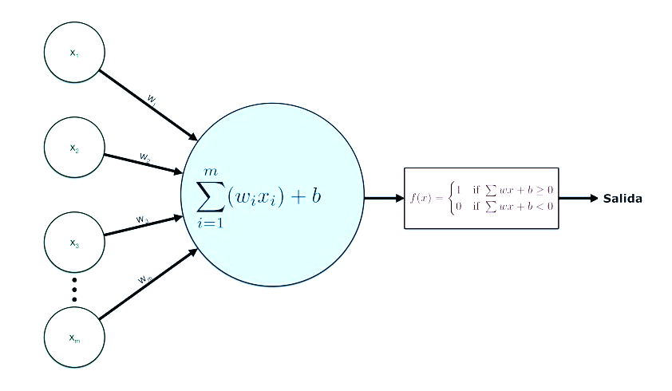

## Ejemplo

https://www.allaboutcircuits.com/technical-articles/how-to-perform-classification-using-a-neural-network-introducing-the-perceptron/

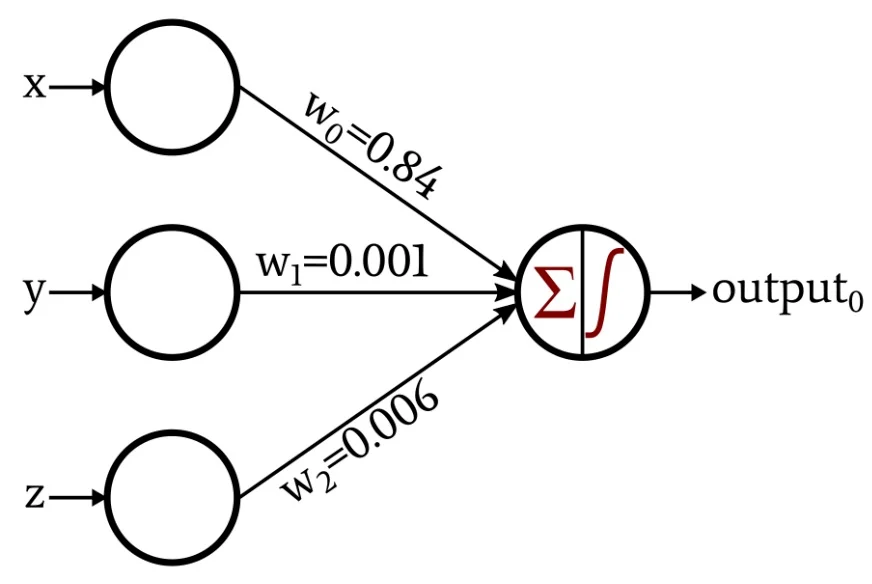

## Nota:

- Observar que los nombres de las matrices y vectores se denominan en mayúscula
- Observar que los nombres de los elementos de un vector o matriz se denominan en minúscula.

### 1. Primer paso: Calcular la sumatoria

$$ a_{temporal} = x w_0 + y w_1 + z w_2 $$

Denominando de una forma mas conveniente:

$ x_0 = x $

$ x_1 = y $

$ x_2 = z $

$$ a_{temporal} = \sum_{i=0}^{n} x_i w_i $$

Revizando los apuntes de algebra vemos que la sumatoria representa el producto escalar entre 2 vectores.

Si denominamos los vectores como sigue:

$ X = [x_0, x_1, x_2, ...., x_n] $ - Vector de entrada X

$ W = [w_0, w_1, w_2, ...., w_n] $ - Vector de pesos W

### Definición 2.2.1 del libro de Algebra.

$$ a_{temporal} = \begin{bmatrix} x_0 & x_1& x_2 & ... & x_n\end{bmatrix} . \begin{bmatrix} w_0\\ w_1\\ w_2\\ ... \\w_n\end{bmatrix} = x_0 w_0 + x_1 w_1 x_2 w_2 + ... + x_n w_n$$

Luego

$$ a_{temporal} = \sum_{i=0}^{n} x_i w_i = X . W $$

## Consideraciones

para poder hacer el producto escalar de 2 vectores, deben:

- tener las misma dimenciones.
- deben estar en la posición correcta.

### 2. Segundo paso: Aplicar la función de activación

$$ a = g(a_{temporal}) = g(X . W) $$

## Analizamos un ejemplo con múltiples entradas y capa oculta y múltiples salidas

Podemos decir que cada nodo conectado a otro nodo es un perceptron. Por lo tanto se aplica lo explicado arriba.

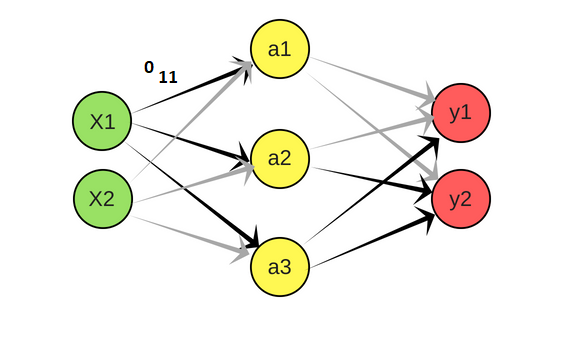

La estructura de una red neuronal es como se observa en la figura

$X = \begin{bmatrix} x_1 & x_2 \end{bmatrix} $ son las entradas en la capa 1

$A = \begin{bmatrix} a_1 & a_2 & a_3 \end{bmatrix} $ activación en la capa 2

$y = \begin{bmatrix} y_1 & y_2 \end{bmatrix} $ son las salidas

Ahora si cada enlace, también conocido como sinápsis, es un número y los podemos agrupar en una matriz a la que denominamos matriz de pesos O

$O_1 = \begin{bmatrix} o_{11} & o_{12} & o_{13}\\ o_{21} & o_{22} & o_{23}\end{bmatrix} $ son las entradas en la capa 1

También podría representar de esta forma:

$O_{1 bis} = \begin{bmatrix} o_{11} & o_{12} \\ o_{21} & o_{22} \\ o_{31} & o_{32} \end{bmatrix} $ son las entradas en la capa 1

Ambas formas son correctas. Pero debemos saber de antemano como disponemos los datos para poder realizar el producto escalar.

$$ A_{temporal} = X * O_1 $$

siempre y cuando se pueda realizar el producto.

Veamos el apartado 2.2.2 del libro de álgebra.

Dice que $ c_{ij} = (renglon_i de A) * (columna_j de B) $

$$c_{ij} = a_{i1}b_{1j} + a_{i2}b_{2j} + ... a_{in}b_{nj} $$

### Definición: Una matriz de m x n es un arreglo rectangular de m por n números arreglados en m renglones y n columnas

1. En el primer paso calculo el producto de X por O, pero debo acomodarlos para poder hacer el producto. X es un vector de 1x2 O_1 es una matriz de 2x3 Como están puedo hacer el producto X por O_1, el orden es 1x2 * 2x3, y devuelve un vector de 1x3

$$ A = X O_1 $$$$ \begin{bmatrix} a_{temp1} & a_{temp2} & a_{temp3}\end{bmatrix} = \begin{bmatrix} x_1 & x_2 \end{bmatrix} . \begin{bmatrix} o_{11} & o_{12} & o_{13}\\ o_{21} & o_{22} & o_{23}\end{bmatrix} $$

De tal manera que:

$$ a_{temp1} = x_1 o_{11} + x_2 o_{21} $$$$ a_{temp2} = x_1 o_{12} + x_2 o_{22}$$$$ a_{temp3} = x_1 o_{13} + x_2 o_{23}$$

Si hubiera definido la matriz de pesos como O_{1bis} ¿Como procedo?

Puedo hacer la traspuesta de X

$$ X^T = \begin{bmatrix} x_1 \\ x_2 \end{bmatrix} $$

Y el producto será:

X^T es un vector de 2x1 O*{1bis} es una matriz de 3x2 Como están puedo hacer el producto $O*{1bis}$ por $X^T$, el orden es 3x2 * 2x1, y devuelve un vector de 3x1

$$ A = O_{1bis} X^T $$$$ \begin{bmatrix} a_{temp1} \\ a_{temp2} \\ a_{temp3}\end{bmatrix} = \begin{bmatrix} o_{11} & o_{12} \\ o_{21} & o_{22} \\ o_{31} & o_{32}\end{bmatrix} \begin{bmatrix} x_1 \\ x_2 \end{bmatrix} $$

De tal manera que:

$$ a_{temp1} = o_{11} x_1 + o_{12} x_2 $$$$ a_{temp2} = o_{21} x_1 + o_{22} x_2 $$$$ a_{temp3} = o_{31} x_1 + o_{32} x_2 $$

1. Aplicar la función de activación: Los cálculos para obtener los valores de activación serán:

$$a_1 = g(a_{temp1})$$$$a_2 = g(a_{temp2})$$$$a_3 = g(a_{temp3})$$

En las ecuaciones, la g es una función Sigmoide que refiere al caso especial de función logística y definida por la fórmula:

$$g(z) = \frac{1}{(1+e^{-z})}$$

## Práctica con matrices

```python
import numpy as np
```

## Vector de entrada

```python
x1=np.array([1,2,3])
print(x1)
```

[output not shown]

## Matriz de pesos

```python
o1=np.array([[4,5,6], [7,8,9]])
o1
```

```
array([[4, 5, 6],
       [7, 8, 9]])
```

### ¿Que tipo de producto es éste?

```python
a1= x1*o1
a1
```

```
array([[ 4, 10, 18],
       [ 7, 16, 27]])
```

## Por que da mal este producto, si es el visto en la explicación anterior?

```python
a11=x1.dot(o1)
a11
```

```
---------------------------------------------------------------------------
ValueError                                Traceback (most recent call last)
<ipython-input-30-406d28b32bef> in <module>
----> 1 a11=x1.dot(o1)
      2 a11

ValueError: shapes (3,) and (2,3) not aligned: 3 (dim 0) != 2 (dim 0)
```

## ¿Porque devuelve un vector de 1x2?

```python
a111=o1.dot(x1)
a111
```

```
array([32, 50])
```

## Arreglando el error

```python
x1=np.array([1,2])
```

## Corresponde al producto escalar X*O1

```python
a11=x1.dot(o1)
a11
```

```
array([18, 21, 24])
```

## Observar: el resultado es el mismo si aplico la traspuesta a ambas matrices.

```python
a111=o1.T.dot(x1.T)
a111
```

```
array([18, 21, 24])
```

## La traspuesta de O1

```python
o1.T
```

```
array([[4, 7],
       [5, 8],
       [6, 9]])
```

## Creando O1bis

```python
o1T=np.array([[4,7],[5,8],[6,9]])
o1T
```

```
array([[4, 7],
       [5, 8],
       [6, 9]])
```

## Corresponde al producto escalar O1bis * X

```python
a112=o1T.dot(x1)
a112
```

```
array([18, 21, 24])
```

## Una red neuronal en Tensorflow Keras

```python
# Create your first MLP in Keras
from keras.models import Sequential
from keras.layers import Dense
import numpy
# fix random seed for reproducibility
numpy.random.seed(7)
# load pima indians dataset
dataset = numpy.loadtxt("https://raw.githubusercontent.com/jbrownlee/Datasets/master/pima-indians-diabetes.data.csv",
                        delimiter=",")
# split into input (X) and output (Y) variables
X = dataset[:,0:8]
Y = dataset[:,8]
# create model
model = Sequential()
model.add(Dense(12, input_dim=8, activation='relu'))
model.add(Dense(8, activation='relu'))
model.add(Dense(1, activation='sigmoid'))
# Compile model
model.compile(loss='binary_crossentropy', optimizer='adam', metrics=['accuracy'])
# Fit the model
model.fit(X, Y, epochs=150, batch_size=10)
# evaluate the model
scores = model.evaluate(X, Y)
print("\n%s: %.2f%%" % (model.metrics_names[1], scores[1]*100))
```

```
accuracy: 78.78%
```

```python
!pip install ann_visualizer
```

## Indagar como instalar Graphviz

```python
!pip install graphviz
```

```python
from ann_visualizer.visualize import ann_viz;

ann_viz(model, title="My first neural network")
```

## Forward Propagation ó red Feedforward

Con Feedforward nos referimos al recorrido de “izquierda a derecha” que hace el algoritmo de la red, para calcular el valor de activación de las neuronas desde las entradas hasta obtener los valores de salida.

Si usamos notación matricial, las ecuaciones para obtener las salidas de la red serán:

$$ X = [x0, x1, x2] $$$$ z_{layer_2} = O_1X $$$$ a_{layer_2} = g(z_{layer_2})$$$$ z_{layer_3} = O_2a_{layer_2}$$$$ y = g(z_{layer_3})$$

Resumiendo: tenemos una red; tenemos 2 entradas, éstas se multiplican por los pesos de las conexiones y cada neurona en la capa oculta suma esos productos y les aplica la función de activación para “emitir” un resultado a la siguiente conexión (concepto conocido en biología como sinapsis química).

# Proceso de clasificación

Dado un conjunto de valores de entrada al que le corresponde una salida específica.

## Programa de cálculo de función XOR

La función XOR es una función booleana, muy utilizada en electrónica digital

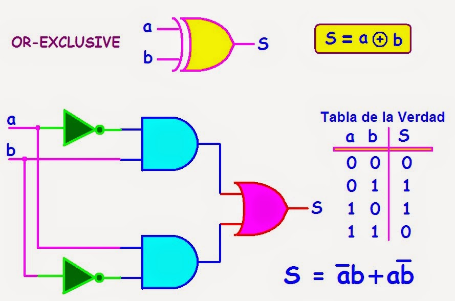

### Una representación gráfica del espacio de dominio

No es una representación cartesina

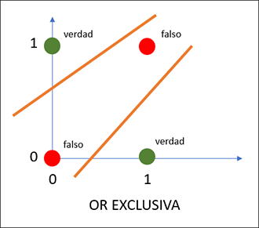

## Llama librerias

```python
import numpy as np
```

## Función de activación

Esta función devuelve la función sigmoide si deriv=False

o la función obtenida de derivar de la función sigmoide. Esta se usa para calcular el ajuste del error.

Conceptos de Análisis Matemático

```python
def sigmoid(x, deriv=False):
    """
    Sigmod retorna un valor entre 0 y 1, es usado para genera la probabilidad
    de un numero.
    https://es.wikipedia.org/wiki/Funci%C3%B3n_sigmoide
    """
    if deriv:
        return x * (1 - x)
    return 1 / (1 + np.exp(-x))
```

## Carga de X e y

Preguntas:

- Indicar las dimensiones de la matriz X y el vector y.

```python
# input data A, B, X
X = np.array([
    [0,0,1],
    [0,1,1],
    [1,0,1],
    [1,1,1],
    ])

# output data Q
y = np.array([
    [0],
    [1],
    [1],
    [0],
    ])
```

## Inicializaciones

Se definen:

1- Semilla para generar números aleatorios.

2- Estructura de la red neuronal

3- Carga matriz de pesos con valores aletorios

## Preguntas:

- Dibujar en Paint esquema estructural de la red neuronal.
- Indicar las dimensiones de la/las matriz de pesos.
- ¿Cuantas matrices de pesos debería tener esta arquitectura?

```python
# setea el generador de num. aleatorios con una semilla conocida = 1
np.random.seed(1)
# Matriz de Sinapsis, es la conección entre una neurona y una capa y todas las neuronas
# de la capa siguinte. https://upload.wikimedia.org/wikipedia/commons/4/46/Colored_neural_network.svg
# Esta red es de 3 layers asi que solo tenemos 2 sinapsis.
#
# capa1 <-- sinapsis0 --> capa2 <-- sinapsis1 --> capa3
n_layers = 3
n_connections = 4
n_outputs = 1

# Matríz de sinapsis 0, conecta el layer 0 con el layer 1
# A [n,n,n,n,]
# B [n,n,n,n,]
# X [n,n,n,n,]
syn0 = 2 * np.random.random((n_layers, n_connections)) - 1
# Matríz de sinapsis 1, conecta el layer 1 con el layer 2
#  Q
# [n]
# [n]
# [n]
# [n]
syn1 = 2 * np.random.random((n_connections, n_outputs)) - 1
```

## Loop de entrenamiento

La matriz X tiene una columna mas, que tiene todos 1. Esta columna se llama **BIAS**. Se usa para mejorar los resultados finales obtenidos.

## Preguntas:

- Leer el código debajo y completar las fómulas que falta.
- Escribir las matrices (con valores simbólicos) syn_0, syn_1, y los productos derivados del cálculo de la red neuronal, o sea, X * syn_0

$$ X=\begin{bmatrix}0 & 0 & 1\\0 & 1 & 1\\ 1 & 0 & 1\\ 1 & 1 & 1\end{bmatrix} $$$$ y=\begin{bmatrix}0 \\ 1\\ 1 \\ 0 \end{bmatrix} $$$$ layer_1 = sigmoid(layer_0*syn_0) $$

- Completar $$ ???=\begin{bmatrix} a \\ b\\ c \\ d \end{bmatrix} $$
- Completar $$ layer_2 = $$
- Completar $$ ???=\begin{bmatrix} a \\ b\\ c \\ d \end{bmatrix} $$
- ¿Que consideraciones debemos tener presentes para poder hacer el producto matricial?
- ¿Cuando aplicamos la función sigmoide, o cualquier otra, que operación matricial es la que se aplica?

## NO ENTRA

### Calculo de gradiente descendiente para corregir el error de la salida vs y(real).

$$ layer_{2err} = y - layer_2 $$$$ layer_{2delta} = layer_{2err} * \frac{\partial y}{\partial {layer_2}} $$$$ layer_{1err} = layer_{2delta} * syn_1^T $$$$ layer_{1delta} = layer_{1err} * \frac{\partial layer_2}{\partial {layer_1}} $$

```python
# Etapa de entrenamiento sobre 100000 iteraciones y cada 10000 mostramos la
# reducción del error.
n_trainning = 100000
n_error_debug = 10000

def xrange(x):
    return iter(range(x))

for j in xrange(n_trainning):
    layer0 = X
    layer1 = sigmoid(np.dot(layer0, syn0))
    layer2 = sigmoid(np.dot(layer1, syn1))
    # Calcula el error entre el layer2 y la salida
    #y es el valor deseado (objetivo) que debe calcular la ANR
    layer2_err = y - layer2
    if (j % n_error_debug) == 0:
        print("Error: " + str(np.mean(np.abs(layer2_err))))

    layer2_delta = layer2_err * sigmoid(layer2, deriv=True)
    layer1_err = layer2_delta.dot(syn1.T)
    layer1_delta = layer1_err * sigmoid(layer1, deriv=True)
    # actualiza el weight (peso), algoritmo gradient descent
    syn1 += layer1.T.dot(layer2_delta)
    syn0 += layer0.T.dot(layer1_delta)

# Finalmente mostramos el resultado
print("Hidden pos entrenamiento")
print (layer1)

# Finalmente mostramos el resultado
print("Output pos entrenamiento")
print (layer2)
```

```
Error: 0.49641003190272537
Error: 0.008584525653247159
Error: 0.0057894598625078085
Error: 0.004629176776769985
Error: 0.003958765280273649
Error: 0.0035101225678616766
Error: 0.003183502385874825
Error: 0.0029323063422830717
Error: 0.0027315064182105086
Error: 0.0025663172400400263
Hidden pos entrenamiento
[[7.46690561e-01 1.11599510e-01 9.28180905e-01 9.97524351e-01]
 [1.58050304e-01 3.46920933e-04 1.62571750e-02 8.99389460e-01]
 [9.97030319e-01 9.00131321e-01 2.16553752e-02 8.48843879e-01]
 [9.55318310e-01 2.42953219e-02 2.83029927e-05 1.10784485e-01]]
Output pos entrenamiento
[[0.00199094]
 [0.99751458]
 [0.99771098]
 [0.00294418]]
```

## Ayuda

Para realizar una clasificación, cuando tenemos un valor de entrada, debemos realizar un procedimiento de cálculo.

Es el mismo que realizamos para entrenar hacia adelante (feed forward), o sea, que tomamos X para predecir y operamos.

## Pregunta

- Implementar la líneas de código que nos permitar arribar al resultado, como se obserba en las siguientes celdas.

```python
a=np.dot(X,syn0)
a
```

```
array([[  1.08108178,  -2.07452528,   2.55908831,   5.99883671],
       [ -1.6728326 ,  -7.96611726,  -4.10283978,   2.19047164],
       [  5.8164231 ,   2.19870617,  -3.8106206 ,   1.72559387],
       [  3.06250872,  -3.69288581, -10.47254869,  -2.08277119]])
```

```python
a_1=sigmoid(a)
a_1
```

```
array([[7.46698645e-01, 1.11597597e-01, 9.28181708e-01, 9.97524506e-01],
       [1.58046885e-01, 3.46903394e-04, 1.62570211e-02, 8.99390592e-01],
       [9.97030605e-01, 9.00133264e-01, 2.16551143e-02, 8.48847960e-01],
       [9.55319502e-01, 2.42950926e-02, 2.83020310e-05, 1.10782682e-01]])
```

## Pregunta

Completar las operaciones que faltan para predecir un X dado, como el que se ve en la celda inferior.

```python
X2=[[1,0,1]]
#a=
#print(a)
#a_1=
#print(a_1)





print(b_1)
```

```
[[0.99771123]]
```

## Este código es muy parecido al anterior, pero organizado en una clase.

## Preguntas

Identificar la arquitectura la esta red neuronal.

Mencione como se denominan las matrices de pesos.

Indique que dimensiones tienen.

```python
import numpy as np
class NeuralNetwork:
    def __init__(self):
        np.random.seed(10) # for generating the same results
        self.wij   = np.random.rand(3,4) # input to hidden layer weights
        self.wjk   = np.random.rand(4,1) # hidden layer to output weights

    def sigmoid(self, x, w):
        z = np.dot(x, w)
        return 1/(1 + np.exp(-z))

    def sigmoid_derivative(self, x, w):
        return self.sigmoid(x, w) * (1 - self.sigmoid(x, w))

    def gradient_descent(self, x, y, iterations):
        for i in range(iterations):
            Xi = x
            Xj = self.sigmoid(Xi, self.wij)
            yhat = self.sigmoid(Xj, self.wjk)
            # gradients for hidden to output weights
            g_wjk = np.dot(Xj.T, (y - yhat) * self.sigmoid_derivative(Xj, self.wjk))
            # gradients for input to hidden weights
            g_wij = np.dot(Xi.T, np.dot((y - yhat) * self.sigmoid_derivative(Xj, self.wjk), self.wjk.T) * self.sigmoid_derivative(Xi, self.wij))
            # update weights
            self.wij += g_wij
            self.wjk += g_wjk
        print('The final prediction from neural network are: ')
        print(yhat)

if __name__ == '__main__':
    neural_network = NeuralNetwork()
    print('Random starting input to hidden weights: ')
    print(neural_network.wij)
    print('Random starting hidden to output weights: ')
    print(neural_network.wjk)
    X = np.array([[0, 0, 1], [1, 1, 1], [1, 0, 1], [0, 1, 1]])
    y = np.array([[0, 1, 1, 0]]).T
    neural_network.gradient_descent(X, y, 10000)
```

```
Random starting input to hidden weights:
[[0.77132064 0.02075195 0.63364823 0.74880388]
 [0.49850701 0.22479665 0.19806286 0.76053071]
 [0.16911084 0.08833981 0.68535982 0.95339335]]
Random starting hidden to output weights:
[[0.00394827]
 [0.51219226]
 [0.81262096]
 [0.61252607]]
The final prediction from neural network are:
[[0.00572029]
 [0.99442052]
 [0.99527493]
 [0.00467507]]
```

```python
np.insert(X,[0,0,0],1)
```

```
array([1, 1, 1, 0, 0, 1, 1, 1, 1, 1, 0, 1, 0, 1, 1])
```

### Predecimos la salida para X=[0,1]

## Pregunta:

¿Es correcto el valor de la salida, si la función es XOR?

```python
X1_1=[[0,1,1]]
aa1=neural_network.sigmoid(X1_1,neural_network.wij)
bb1=neural_network.sigmoid(aa1,neural_network.wjk)
print(bb1)
```

```
[[0.00467482]]
```

```python
x= np.array([1,2,3])
x
```

```
array([1, 2, 3])
```

```python
np.append(x,2)
```

```
array([1, 2, 3, 2])
```

```python
v=np.matrix([[1,2,3],[4,5,6]])
v
```

```
matrix([[1, 2, 3],
        [4, 5, 6]])
```

```python
a = np.array([[1, 1], [2, 2], [3, 3]])

np.insert(a, 1, 5)
```

```
array([1, 5, 1, 2, 2, 3, 3])
```